# Stripe Recurring Topup Feature Release Analysis

Dani Mermelstein

2020-10-14

# TL;DR

Subsequent (AKA Recurring) TopUp program total revenue is $22k (best-base scenario), and total cost is $31k (below our initial $50k budget). It’s possible Stripe recurring topup gets more people to deposit more money but doesn’t get them to stay MAU longer.

Recurring topups are probably costing us about $3,000 per month. This best-case scenario analysis assumes all deposits are spent via cards and we benefit from 0.83% in interchange revenue, plus the 1% fee we currently charge. We incorporate stripe/network, dispute loss and dispute fees into the costs. We only factor in confirmed fraud but not potential fraud.

For more detail on the dollar cost and revenue of running this feature so far, see [this document](https://docs.google.com/spreadsheets/d/1mydy67256PEe1AFBGTr7dD0x2-TYs-1V/edit#gid=643625962).

## Recommendations and further discussion

Overall, the total cost of the subsequent top-up program has been less compared to the original forecast, and we are seeing some potential improvements in funding amount and frequency for topup users. There are some confusing and opposing results (see the Caveats section), and therefore all outputs should be taken with a grain of salt.

What do we do now? We are currently planning to increase the recurring topup fee from 1% to 3% around the end of October. We could proceed with that, or if we’re willing to eat the program cost for now we could keep the fee at 1%. If we were to do an A/B test with new users we could redo this analysis with much higher accuracy, as well as better understand whether Stripe recurring topup is cannibalizing any other deposit methods; we could then also better weigh the costs and benefits associated with this funding method.

## Caveats

**THIS WAS NOT AN A/B TEST**. All analysis here, with the exception of *Stripe Radar Risk Scores*, was done as a pre/post analysis. Some analysis required covering large amounts of time (see the *lapse rate* analysis). This means our analysis could be influenced by a variety of factors, including:

- changes in market sentiment
- differences between cohorts
- changes to the unemployment rate (unfortunately a major factor this summer)
- changes in fraudulent user behavior (we filtered out all confirmed fraud cases, but we might not have caught all of it)
- marketing/acquisition efforts that happened at different periods
- etc…

# Analysis

## Incremental Funding Rate

Data is within 14 days of KYC Complete for a 7 day cohort

**These results are significant**

estimated lift: 12%

| category | min_kyc | max_kyc |
| --- | --- | --- |
| pre | 2020-06-30 20:01:28 | 2020-07-07 19:59:15 |
| post | 2020-07-21 20:00:21 | 2020-07-28 19:57:40 |

| Variants | Users | Outcomes | Funding.Rate |
| --- | --- | --- | --- |
| pre_launch | 3773 | 530 | 0.1404718 |
| post_launch | 3222 | 504 | 0.1564246 |

### 90% Confidence Interval:

```
##         5%        95%
## 0.01347405 0.22436926
```

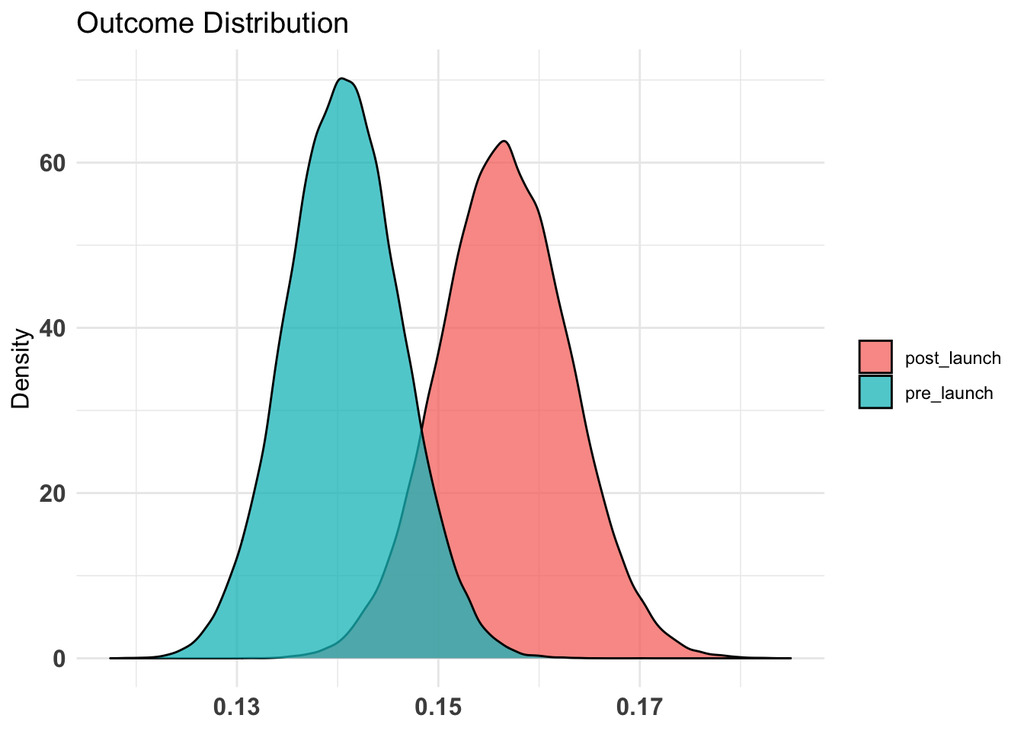

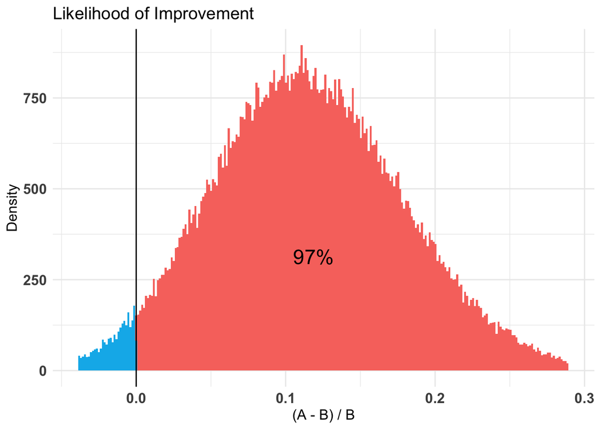

## Stripe Radar Risk Scores

for all topup txns after 2020-07-22

Differences in average risk scores for first vs recurring topups are statistically significant

| topup_type | avg_risk_score |
| --- | --- |
| first | 13.37668 |
| recurring | 17.69725 |

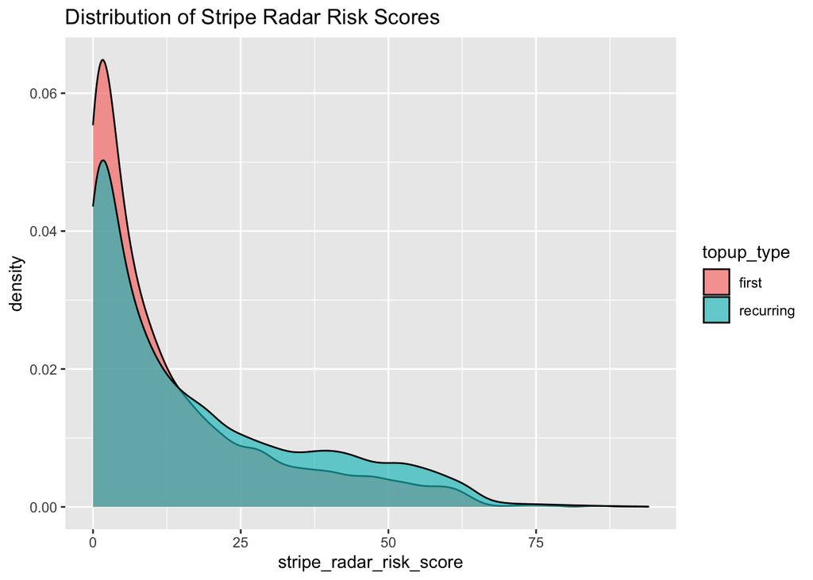

## Funding Amounts

Data is within 14 days of KYC Complete for a 7 day cohort

| category | min_kyc | max_kyc |
| --- | --- | --- |
| pre | 2020-06-30 20:01:28 | 2020-07-07 19:59:15 |
| post | 2020-07-21 20:00:21 | 2020-07-28 19:57:40 |

### Overall Funding

Differences in total funding amounts per user from before to after product launch do NOT appear to be statistically significant

| category | avg_total_amount_per_user | users |
| --- | --- | --- |
| post | 517.1382 | 504 |
| pre | 684.5660 | 530 |

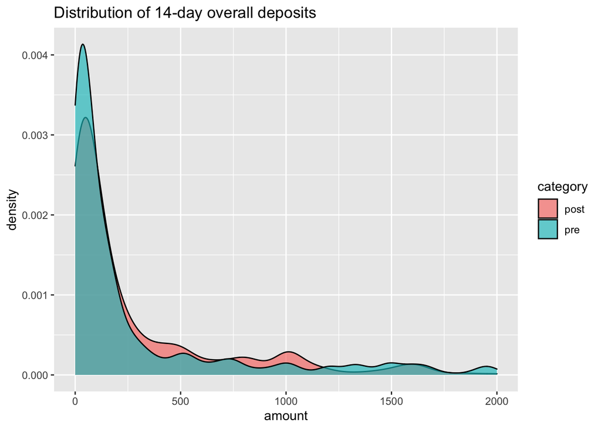

### Topup Users Only

Differences in total funding amounts per user from before to after product launch appear to be statistically significant

estimated overall funding lift: 47%

| category | avg_total_topup_amount_per_user | users |
| --- | --- | --- |
| post | 260.1182 | 197 |
| pre | 176.3678 | 197 |

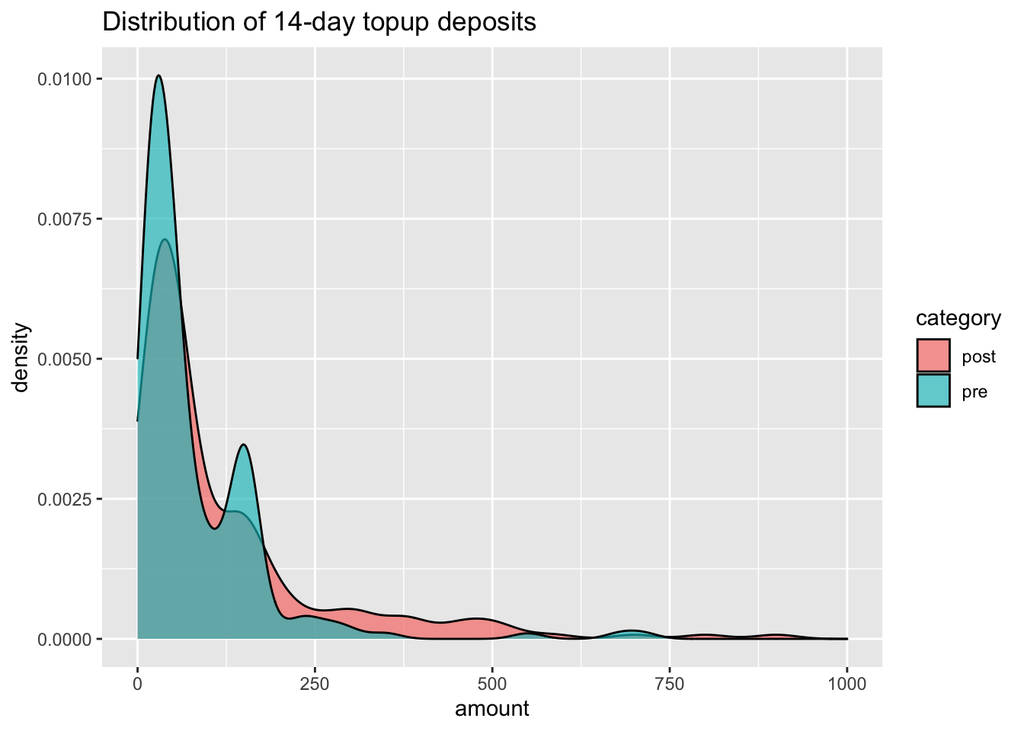

## Lapse Rates

Looking at 8-week lapse rates for a 2-week cohort of users pre/post the product launch on July 22

**These results are NOT significant**

estimated lift: 2%

| category | mau_group | users | total | rate |
| --- | --- | --- | --- | --- |
| post | full_lapse | 354 | 1166 | 0.3036021 |
| post | reactivated | 50 | 1166 | 0.0428816 |
| post | unbroken_mau | 762 | 1166 | 0.6535163 |
| pre | full_lapse | 511 | 1618 | 0.3158220 |
| pre | reactivated | 65 | 1618 | 0.0401731 |
| pre | unbroken_mau | 1042 | 1618 | 0.6440049 |

| Variants | Users | Outcomes | Unbroken.MAU.Rate |
| --- | --- | --- | --- |
| pre_launch | 1618 | 1042 | 0.6440049 |
| post_launch | 1166 | 762 | 0.6535163 |

### 90% Confidence Interval:

```
##          5%         95%
## -0.03152993  0.06268906
```

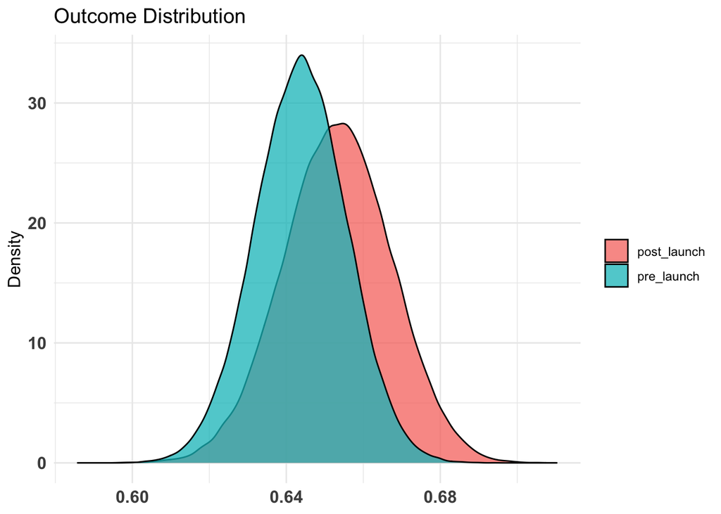

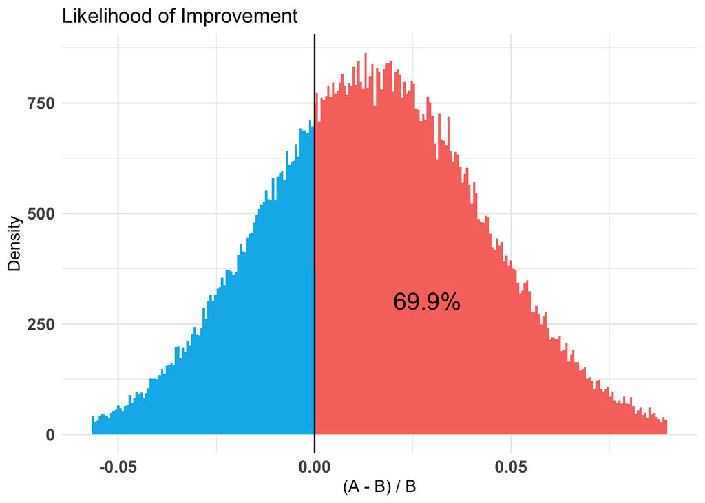